# Flight Model

Max Czapanskiy

11 November, 2017

```r
knitr::opts_chunk$set(
  message = FALSE,
  warning = FALSE
)
library(dplyr)
library(lubridate)
library(tidyr)
library(ggplot2)
library(foreach)
library(RSQLite)
library(doParallel)
library(iterators)
library(glmmADMB)
library(knitr)
library(akima)
library(rgdal)

# dplyr connections
MHI_db <- src_sqlite('../data/MHI_GPS.sqlite')
metadata_db <- tbl(MHI_db, 'Metadata')
tidytracks_db <- tbl(MHI_db, 'TidyTracks')
acceleration_db <- tbl(MHI_db, 'SegmentACC')

POSIX.origin = ymd('1970-01-01', tz = 'UTC')

# Load data from earlier reports
load('../data/out/TransitSegments/Segments.RData')
load('../data/out/TransitSegments/ValidSegments.RData')
load('../data/out/TransitSegments/AccSegments.RData')
load('../data/out/TransitSegments/WindSegments.RData')

select <- dplyr::select
```

How do seabirds modulate flight behavior in response to wind? This report seeks to answer that question by modeling the flap ratio as a function of tail- (`T`) and crosswinds (`C`) with individual bird (`B`) and trip (`R`) as random effects.

First up: segment sampling. Randomly select both an outbound and inbound segment from each eligible trip (i.e. trips *both* outbound and inbound segments).

```r
# Which trips have both outbound and inbound legs?
bothLegs <- windSegments %>%
  group_by(DeployID, TripID, Leg) %>%
  summarize(N = n()) %>%
  ungroup %>%
  spread(Leg, N) %>%
  mutate(Both = !is.na(Inbound) & !is.na(Outbound)) %>%
  filter(Both)

set.seed(211)
segSample <- windSegments %>%
  semi_join(bothLegs, by = 'TripID') %>%
  group_by(TripID, Leg) %>%
  sample_n(1) %>%
  ungroup

save(segSample, file = '../data/out/TransitSegments/SegSample.RData')
```

Let’s look at the distribution of segments across deployments, time, and location.

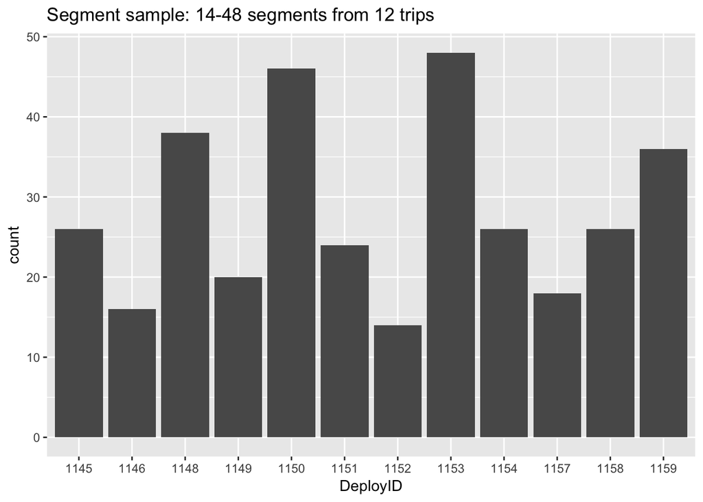

```r
# Across deployments
ggplot(segSample, aes(x = DeployID)) +
  geom_bar() +
  labs(title = 'Segment sample: 14-48 segments from 12 trips')
```

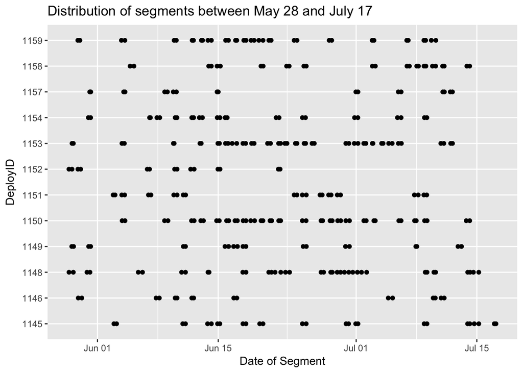

```r
# Through time
ggplot(segSample, aes(x = Start, y = DeployID)) +
  geom_point() +
  labs(x = 'Date of Segment',
       title = 'Distribution of segments between May 28 and July 17')
```

```r
# In space
ColLon <- -159.3997
ColLat <- 22.22888
LonExtent <- c(min(ColLon, segSample$Longitude), max(ColLon, segSample$Longitude))
LatExtent <- c(min(ColLat, segSample$Latitude), max(ColLat, segSample$Latitude))
hi_shp <- readOGR('../data/coastline/ne_10m_coastline/', 'ne_10m_coastline')
```

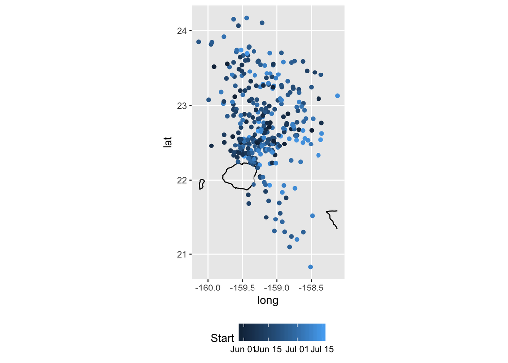

```r
hi_df <- fortify(hi_shp) %>%
  filter(between(long, LonExtent[1], LonExtent[2]),
         between(lat, LatExtent[1], LatExtent[2]))
ggplot(segSample) +
  geom_path(data = hi_df, aes(x = long, y = lat, group = group)) +
  geom_point(aes(x = Longitude, y = Latitude, color = Start)) +
  coord_map() +
  theme(legend.position = 'bottom')
```

Now a look at the response varible (FlapRatio) in response to the predictor variables (T, C, L)

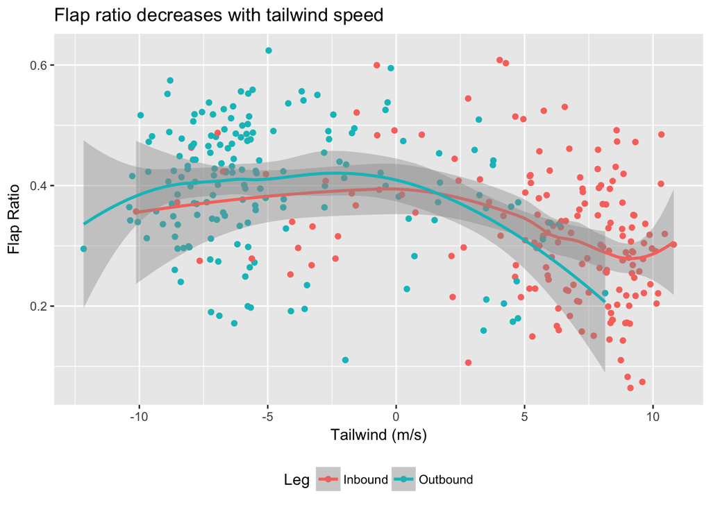

```r
# F ~ T by L
ggplot(segSample, aes(x = Tailwind, y = FlapRatio, color = Leg)) +
  geom_point() +
  geom_smooth(method = 'loess') +
  labs(x = 'Tailwind (m/s)',
       y = 'Flap Ratio',
       title = 'Flap ratio decreases with tailwind speed') +
  theme(legend.position = 'bottom')
```

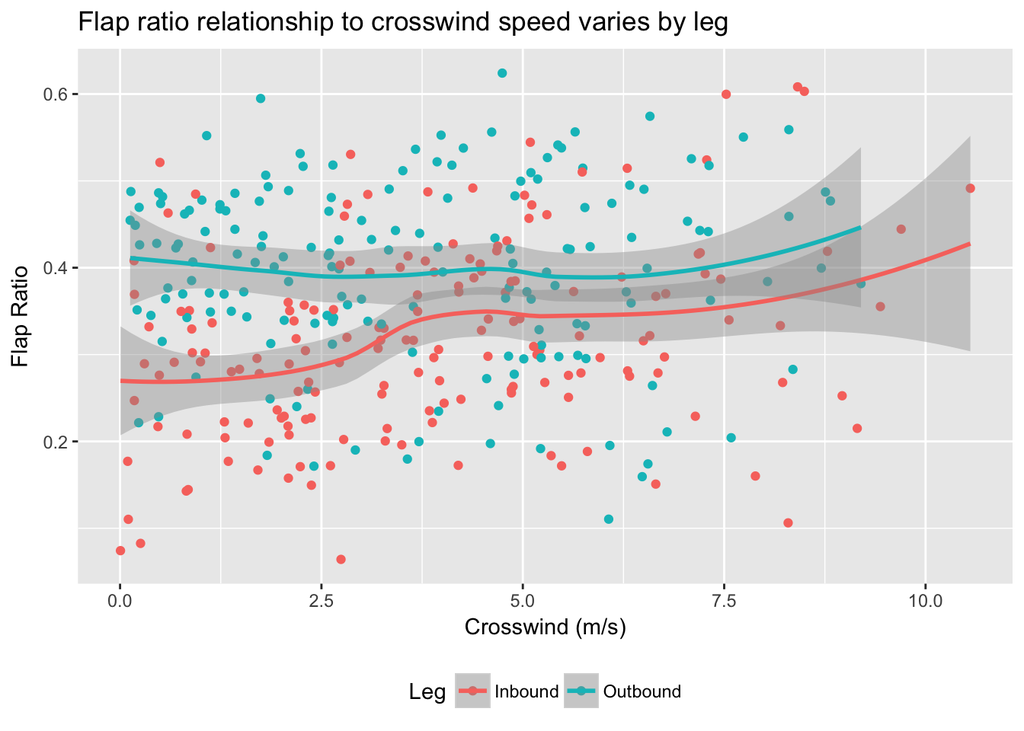

```r
# F ~ C by L
ggplot(segSample, aes(x = Crosswind, y = FlapRatio, color = Leg)) +
  geom_point() +
  geom_smooth(method = 'loess') +
  labs(x = 'Crosswind (m/s)',
       y = 'Flap Ratio',
       title = 'Flap ratio relationship to crosswind speed varies by leg') +
  theme(legend.position = 'bottom')
```

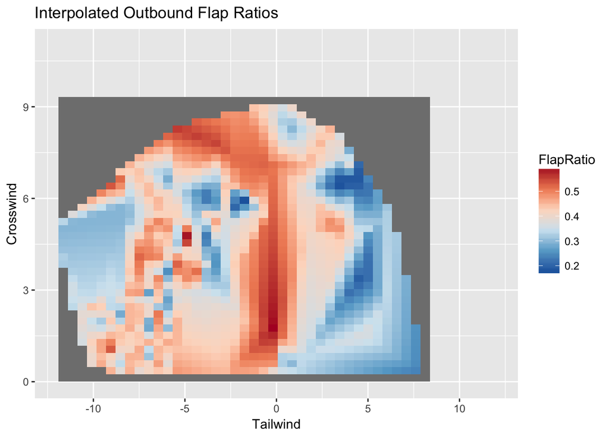

```r
# F ~ T:C by L
interp.seg.out <- with(filter(segSample, Leg == 'Outbound'),
                       interp(Tailwind, Crosswind, FlapRatio))
expand.grid(i = seq(interp.seg.out$x),
            j = seq(interp.seg.out$y)) %>%
  mutate(Tailwind = sapply(i, function(a) interp.seg.out$x[a]),
         Crosswind = sapply(j, function(b) interp.seg.out$y[b]),
         FlapRatio = mapply(function(a, b) interp.seg.out$z[a, b], i, j)) %>%
  ggplot(aes(x = Tailwind, y = Crosswind, fill = FlapRatio)) +
  geom_tile() +
  xlim(-12, 12) +
  ylim(0, 11) +
  scale_fill_distiller(palette = 'RdBu') +
  labs(title = 'Interpolated Outbound Flap Ratios')
```

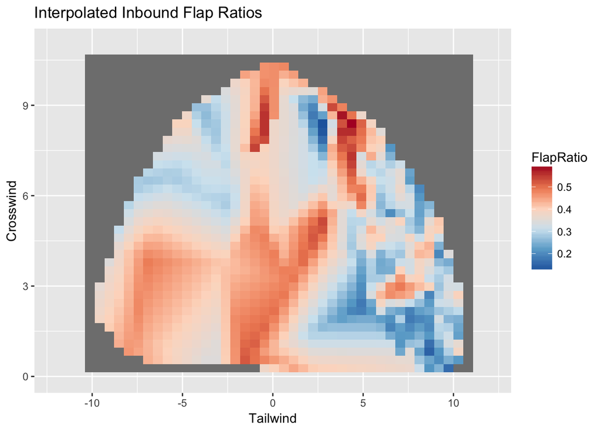

```r
interp.seg.in <- with(filter(segSample, Leg == 'Inbound'),
                       interp(Tailwind, Crosswind, FlapRatio))
expand.grid(i = seq(interp.seg.in$x),
            j = seq(interp.seg.in$y)) %>%
  mutate(Tailwind = sapply(i, function(a) interp.seg.in$x[a]),
         Crosswind = sapply(j, function(b) interp.seg.in$y[b]),
         FlapRatio = mapply(function(a, b) interp.seg.in$z[a, b], i, j)) %>%
  ggplot(aes(x = Tailwind, y = Crosswind, fill = FlapRatio)) +
  geom_tile() +
  xlim(-12, 12) +
  ylim(0, 11) +
  scale_fill_distiller(palette = 'RdBu') +
  labs(title = 'Interpolated Inbound Flap Ratios')
```

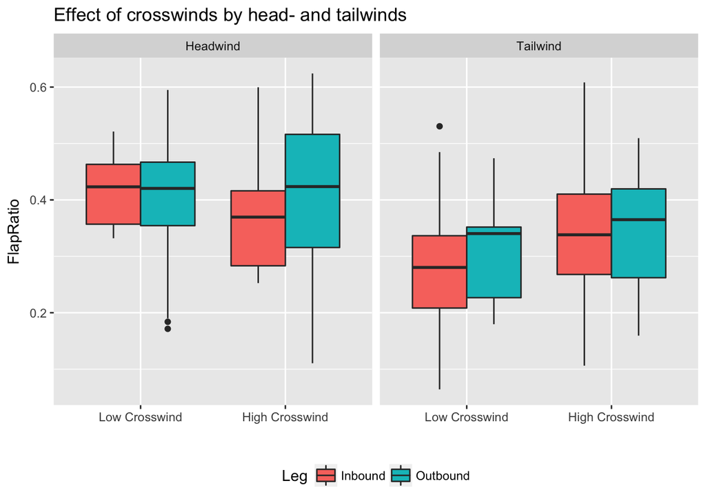

```r
# Distribution of F by T, C categories
segSample %>%
  mutate(Tcat = factor(ifelse(Tailwind < 0, 'Headwind', 'Tailwind')),
         Ccat = factor(ifelse(Crosswind < median(Crosswind), 'Low Crosswind', 'High Crosswind'),
                       levels = c('Low Crosswind', 'High Crosswind'))) %>%
  ggplot(aes(x = Ccat, y = FlapRatio, fill = Leg)) +
  geom_boxplot() +
  facet_grid(. ~ Tcat) +
  labs(x = '',
       title = 'Effect of crosswinds by head- and tailwinds') +
  theme(legend.position = 'bottom')
```

## Determine random effects structure

Starting with the maximal fixed effects model (`F ~ T * C`) rank the potential random effects structures (where TripID < DeployID) by AIC

```r
# List to store random effects model formulae
re.form <- list()
# Formula of maximal fixed effects
fe.max <- FlapRatio ~ Tailwind * Crosswind

# Intercepts
re.form[[1]] <- ~ . + (1|DeployID)
re.form[[2]] <- ~ . + (1|TripID)

# Slopes by DeployID
re.form[[3]] <- ~ . +  (Tailwind|DeployID)
re.form[[4]] <- ~ . + (Crosswind|DeployID)
re.form[[5]] <- ~ . + (Tailwind|DeployID) + (Crosswind|DeployID)

# Slopes by TripID
re.form[[6]] <- ~ . + (Tailwind|TripID)
re.form[[7]] <- ~ . + (Crosswind|TripID)
re.form[[8]] <- ~ . + (Tailwind|TripID) + (Crosswind|TripID)

# Interaction by DeployID and TripID
re.form[[9]] <- ~ . + (Tailwind:Crosswind|DeployID)
re.form[[10]] <- ~ . + (Tailwind:Crosswind|TripID)

# Function for converting formulae to strings
char.formula <- function(f) {
  mod.parts <- as.character(f) %>%
    gsub('FlapRatio', 'F', .) %>%
    gsub('Tailwind', 'T', .) %>%
    gsub('Crosswind', 'C', .) %>%
    gsub('DeployID', 'B', .) %>%
    gsub('TripID', 'R', .)
  if(length(mod.parts) == 2)
    paste(mod.parts, collapse = ' ')
  else
    paste(mod.parts[1], mod.parts[3])
}
```

```r
# Fit models
modCl <- makeCluster(detectCores() - 1, type = 'FORK')
registerDoParallel(modCl)
re.mod <- foreach(f = re.form) %dopar% {
  mod.formula <- update.formula(fe.max, f)
  tryCatch(glmmadmb(mod.formula, segSample, family = 'beta'), error = function(e) NULL)
}
stopCluster(modCl)

# Save random effects models
save(re.mod, file = '../data/out/Models/REmodelsNoLeg.RData')
```

```r
load('../data/out/Models/REmodelsNoLeg.RData')
# Summarize models by AIC
re.summ <- foreach(f = re.form,
                   m = re.mod,
                   .combine = rbind) %do% {
  re.formula <- char.formula(f)
  if(is.null(m)) {
    data.frame(Formula = re.formula,
               AIC = NA)
  } else {
    data.frame(Formula = re.formula,
               AIC = AIC(m))
  }
} %>%
  mutate(dAIC = AIC - min(AIC, na.rm = TRUE),
         rellik = exp(-0.5 * dAIC),
         AICw = rellik/sum(rellik, na.rm = TRUE)) %>%
  select(-rellik) %>%
  arrange(dAIC)

# Print table
kable(re.summ, digits = 3)
```

| Formula | AIC | dAIC | AICw |
| --- | --- | --- | --- |
| ~ . + (1 \| B) | -636.306 | 0.000 | 0.353 |
| ~ . + (T:C \| B) | -636.282 | 0.024 | 0.349 |
| ~ . + (C \| B) | -634.490 | 1.816 | 0.143 |
| ~ . + (T \| B) | -634.380 | 1.926 | 0.135 |
| ~ . + (T \| B) + (C \| B) | -630.536 | 5.770 | 0.020 |
| ~ . + (T:C \| R) | -586.090 | 50.216 | 0.000 |
| ~ . + (1 \| R) | -582.940 | 53.366 | 0.000 |
| ~ . + (C \| R) | -582.612 | 53.694 | 0.000 |
| ~ . + (T \| R) | NA | NA | NA |
| ~ . + (T \| R) + (C \| R) | NA | NA | NA |

Based on AICw the top ranked random effects structures are `(1|B)` and `(T:C|B)`. `(C|B)` and `(T|B)` also delta AIC less than 2. We’ll try all four in determining fixed effects structure.

## Determine fixed effects structure

Using the optimal random effects structures, determine best fitting fixed effects structure

```r
# List to store fixed effects model formulae
me.form <- list()
# Formulae of optimal random effects structures
re.optim1 <- FlapRatio ~ (1|DeployID)
re.optim2 <- FlapRatio ~ (Tailwind:Crosswind|DeployID)
re.optim3 <- FlapRatio ~ (Crosswind|DeployID)
re.optim4 <- FlapRatio ~ (Tailwind|DeployID)

# Mixed effects to test with (1|B)
me.form[[1]] <- list(~ . + Tailwind * Crosswind, re.optim1)
me.form[[2]] <- list(~ . + Tailwind + Crosswind, re.optim1)
me.form[[3]] <- list(~ . + Tailwind, re.optim1)
me.form[[4]] <- list(~ . + Crosswind, re.optim1)

# Mixed effects to test with (T:C|B)
me.form[[5]] <- list(~ . + Tailwind * Crosswind, re.optim2)
me.form[[6]] <- list(~ . + Tailwind + Crosswind, re.optim2)

# Mixed effects to test with (C|B)
me.form[[7]] <- list(~ . + Tailwind * Crosswind, re.optim3)
me.form[[8]] <- list(~ . + Tailwind + Crosswind, re.optim3)
me.form[[9]] <- list(~ . + Crosswind, re.optim3)

# Mixed effects to test with (T|B)
me.form[[10]] <- list(~ . + Tailwind * Crosswind, re.optim4)
me.form[[11]] <- list(~ . + Tailwind + Crosswind, re.optim4)
me.form[[12]] <- list(~ . + Tailwind, re.optim4)
```

```r
# Fit models
modCl <- makeCluster(detectCores() - 1, type = 'FORK')
registerDoParallel(modCl)
me.mod <- foreach(f = me.form,
                  i = seq_along(re.form)) %dopar% {
  # Update
  mod.formula <- update.formula(f[[2]], f[[1]])
  tryCatch(glmmadmb(mod.formula, segSample, family = 'beta'), error = function(e) NULL)
}
stopCluster(modCl)

# Save mixed effects models
save(me.mod, file = '../data/out/Models/MEmodelsNoLeg.RData')
```

```r
load('../data/out/Models/MEmodelsNoLeg.RData')
# Summarize models by AIC
me.summ <- foreach(f = me.form,
                   m = me.mod,
                   .combine = rbind) %do% {
  fe.formula <- char.formula(f[[1]])
  re.formula <- char.formula(f[[2]])

  if(is.null(m)) {
    data.frame(FixedEffects = fe.formula,
               RandomEffects = re.formula,
               AIC = NA)
  } else {
    data.frame(FixedEffects = fe.formula,
               RandomEffects = re.formula,
               AIC = AIC(m))
  }
} %>%
  mutate(dAIC = AIC - min(AIC, na.rm = TRUE),
         rellik = exp(-0.5 * dAIC),
         AICw = rellik/sum(rellik, na.rm = TRUE)) %>%
  select(-rellik) %>%
  arrange(dAIC)

# Print table
kable(me.summ, digits = 3)
```

| FixedEffects | RandomEffects | AIC | dAIC | AICw |
| --- | --- | --- | --- | --- |
| ~ . + T * C | ~ (1 \| B) | -636.306 | 0.000 | 0.290 |
| ~ . + T * C | ~ (T:C \| B) | -636.282 | 0.024 | 0.287 |
| ~ . + T * C | ~ (C \| B) | -634.490 | 1.816 | 0.117 |
| ~ . + T * C | ~ (T \| B) | -634.380 | 1.926 | 0.111 |
| ~ . + T + C | ~ (1 \| B) | -633.776 | 2.530 | 0.082 |
| ~ . + T + C | ~ (T:C \| B) | -633.570 | 2.736 | 0.074 |
| ~ . + T + C | ~ (C \| B) | -631.870 | 4.436 | 0.032 |
| ~ . + T | ~ (1 \| B) | -628.936 | 7.370 | 0.007 |
| ~ . + C | ~ (1 \| B) | -555.814 | 80.492 | 0.000 |
| ~ . + C | ~ (C \| B) | -553.814 | 82.492 | 0.000 |

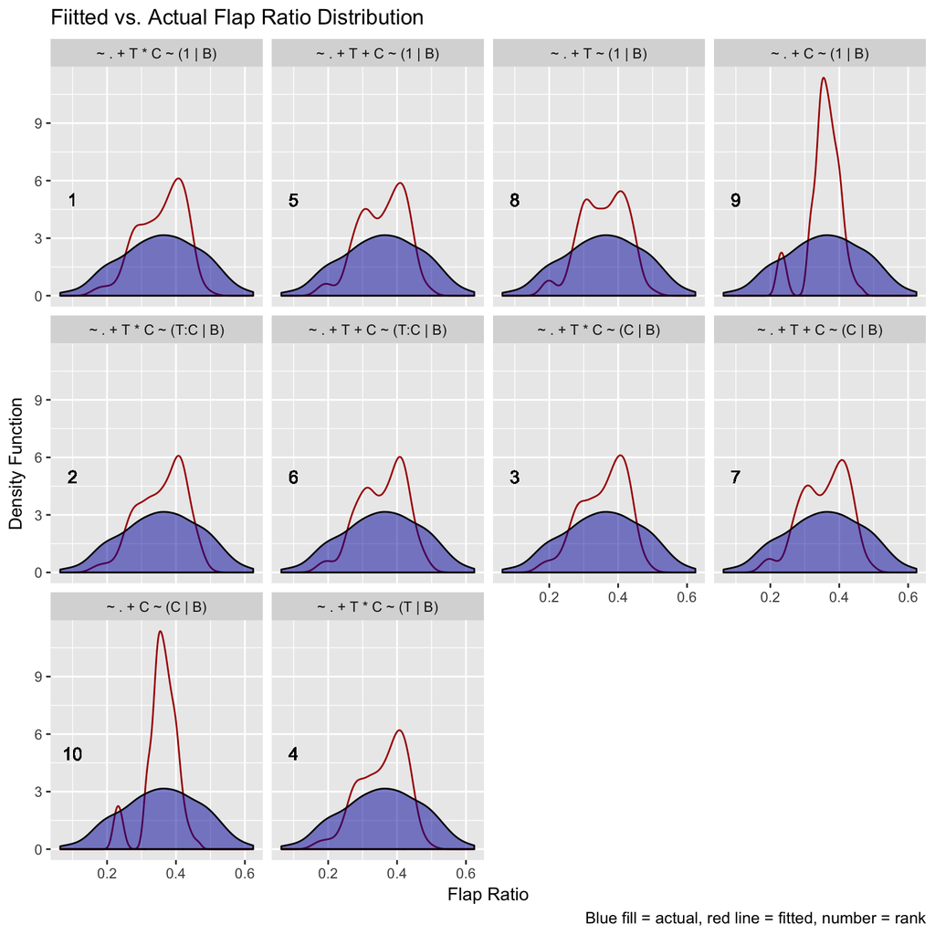

```r
# Compare actual/predicted distributions
mod.rank <- foreach(f = me.form,
                    m = me.mod,
                    .combine = rbind) %do% {
  data.frame(mod.lbl = paste(char.formula(f[[1]]), char.formula(f[[2]])),
             mod.aic = AIC(m))
} %>%
  mutate(mod.rank = rank(mod.aic))
foreach(f = me.form,
        m = me.mod,
        .combine = rbind) %do% {
  data.frame(mod.lbl = paste(char.formula(f[[1]]), char.formula(f[[2]])),
             mod.fitted = m$fitted)
} %>%
  left_join(mod.rank) %>%
  ggplot(aes(x = mod.fitted)) +
  geom_density(color = '#AA0000') +
  facet_wrap(~ mod.lbl) +
  geom_density(data = me.mod[[1]]$frame,
               aes(x = FlapRatio),
               fill = '#0000AA',
               alpha = 0.5) +
  geom_text(aes(label = mod.rank), x = 0.1, y = 5) +
  labs(x = 'Flap Ratio',
       y = 'Density Function',
       title = 'Fiitted vs. Actual Flap Ratio Distribution',
       caption = 'Blue fill = actual, red line = fitted, number = rank')
```

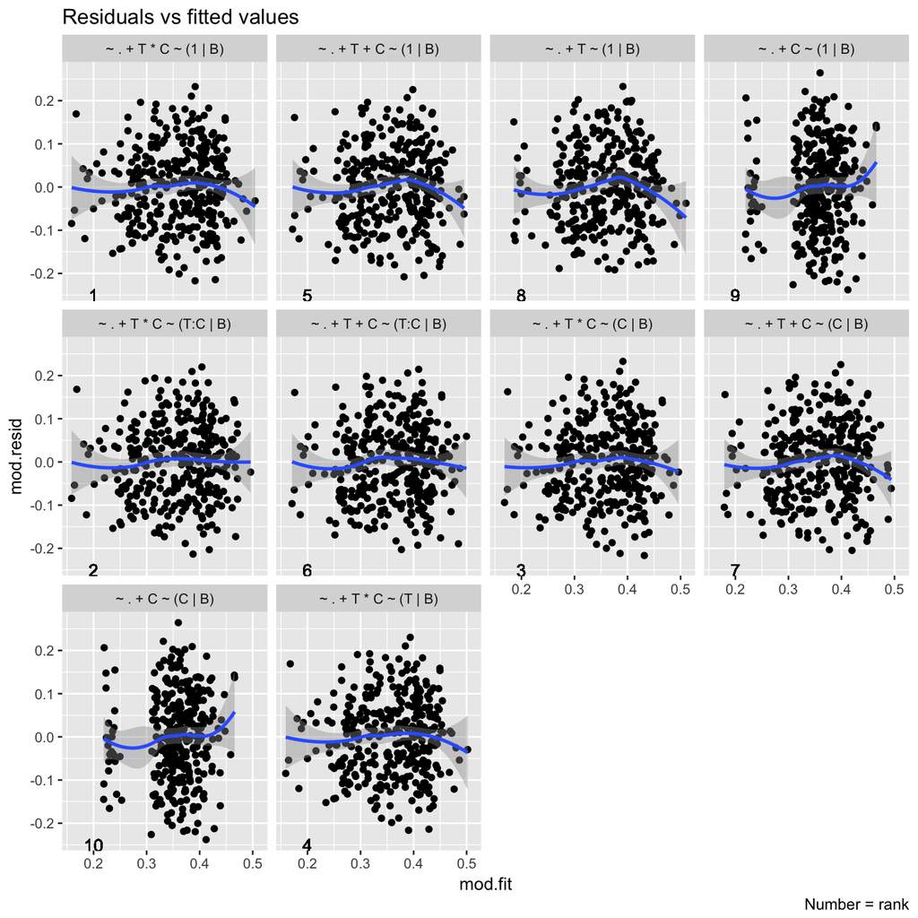

```r
# Residuals vs fitted
foreach(f = me.form,
        m = me.mod,
        .combine = rbind) %do% {
  data.frame(mod.lbl = paste(char.formula(f[[1]]), char.formula(f[[2]])),
             mod.resid = m$residuals,
             mod.fit = m$fitted)
} %>%
  left_join(mod.rank) %>%
  ggplot(aes(x = mod.fit, y = mod.resid)) +
  geom_point() +
  geom_smooth() +
  geom_text(aes(label = mod.rank), x = 0.2, y = -0.25) +
  facet_wrap(~ mod.lbl) +
  labs(title = 'Residuals vs fitted values',
       caption = 'Number = rank')
```

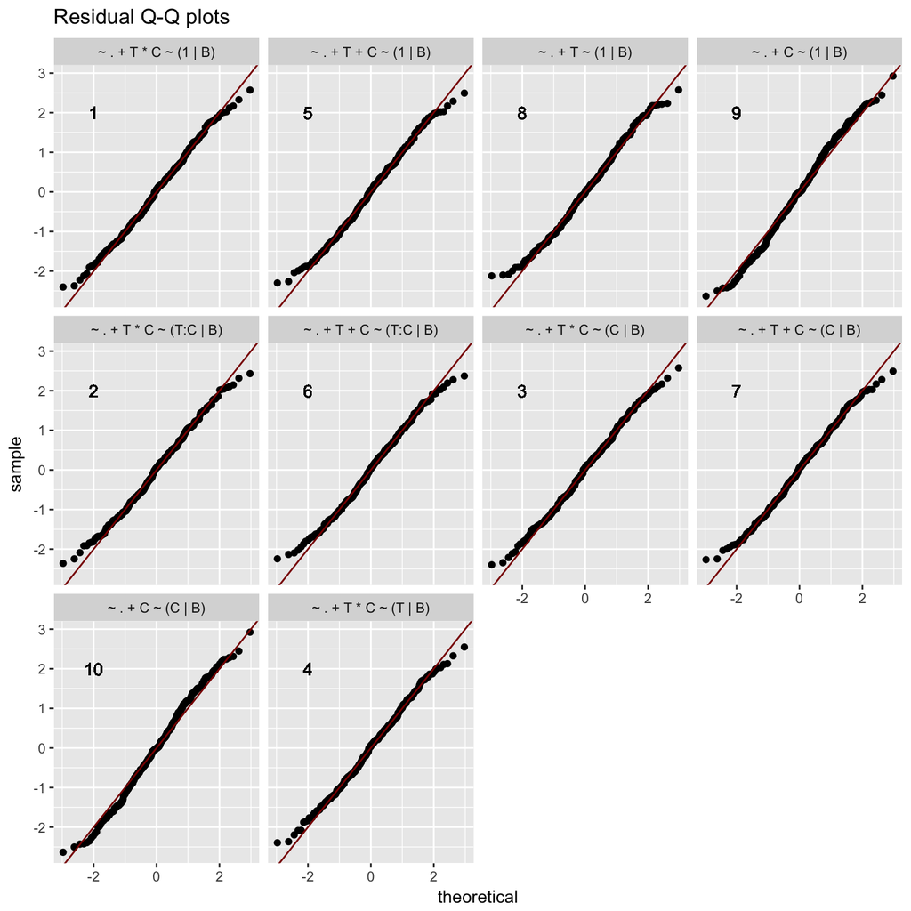

```r
# QQ plots
foreach(f = me.form,
        m = me.mod,
        .combine = rbind) %do% {
  data.frame(mod.lbl = paste(char.formula(f[[1]]), char.formula(f[[2]])),
             mod.resid = m$residuals)
} %>%
  left_join(mod.rank) %>%
  ggplot(aes(sample = mod.resid / sd(mod.resid))) +
  stat_qq() +
  geom_abline(slope = 1, intercept = 0, color = 'darkred') +
  facet_wrap(~ mod.lbl) +
  geom_text(aes(label = mod.rank), x = -2, y = 2) +
  labs(title = 'Residual Q-Q plots')
```

The highest ranking mixed effects models are `F ~ T * C + (1 | B)` and `F ~ T * C + (T:C | B)`. The latter has more homogeneous residuals, so we will use that as the flight model.

## Model diagnostics

```r
flight.model <- me.mod[[5]]
summary(flight.model)
```

```
##
## Call:
## glmmadmb(formula = mod.formula, data = segSample, family = "beta")
##
## AIC: -636.3
##
## Coefficients:
##                    Estimate Std. Error z value Pr(>|z|)
## (Intercept)        -0.66726    0.07937   -8.41  < 2e-16 ***
## Tailwind           -0.04161    0.00600   -6.93  4.1e-12 ***
## Crosswind           0.02337    0.00950    2.46    0.014 *
## Tailwind:Crosswind  0.00400    0.00185    2.16    0.031 *
## ---
## Signif. codes:  0 '***' 0.001 '**' 0.01 '*' 0.05 '.' 0.1 ' ' 1
##
## Number of observations: total=338, DeployID=12
## Random effect variance(s):
## Group=DeployID
##                     Variance   StdDev
## (Intercept)        5.346e-02 0.231210
## Tailwind:Crosswind 6.019e-06 0.002453
##
## Beta dispersion parameter: 27.372 (std. err.: 2.1495)
##
## Log-likelihood: 325.141
```

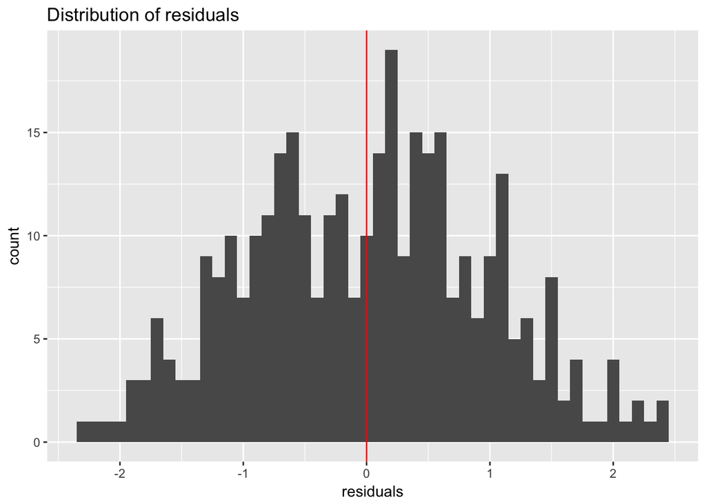

```r
# Histogram of residuals
data.frame(residuals = residuals(flight.model)) %>%
  ggplot(aes(x = residuals)) +
  geom_histogram(binwidth = 0.1) +
  geom_vline(xintercept = 0, color = 'red') +
  labs(title = 'Distribution of residuals')
```

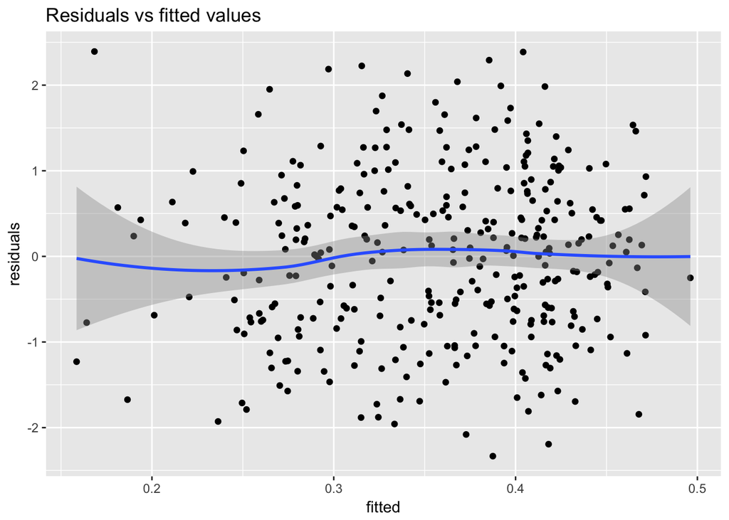

```r
# Residuals vs fitted
data.frame(residuals = residuals(flight.model),
           fitted = fitted(flight.model)) %>%
  ggplot(aes(x = fitted, y = residuals)) +
  geom_point() +
  geom_smooth() +
  labs(title = 'Residuals vs fitted values')
```

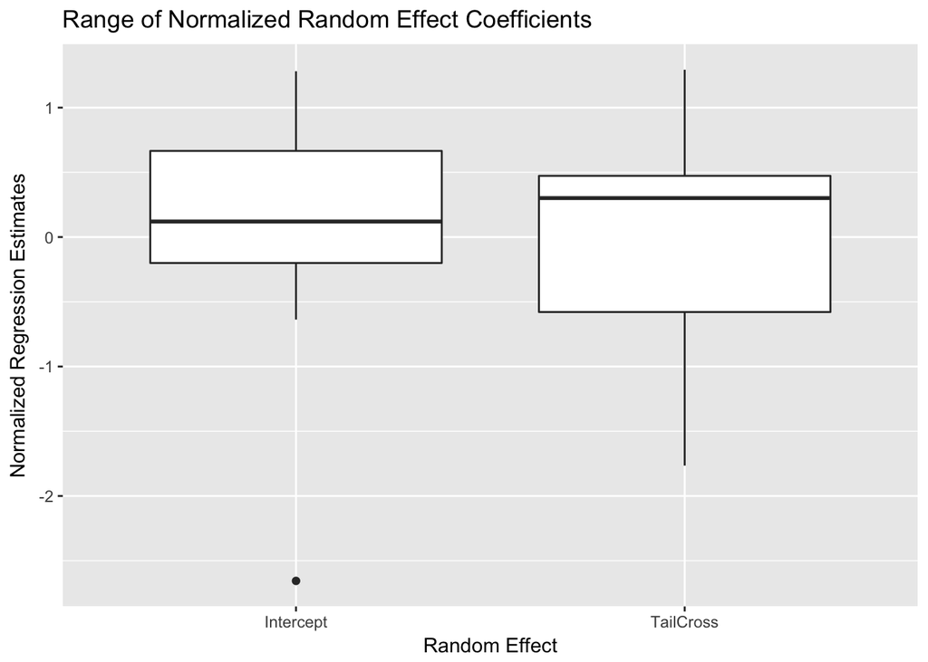

```r
# Random effect coefficient distributions
flight.model.ranef <- data.frame(ranef(flight.model)$DeployID)
colnames(flight.model.ranef) <- c('Intercept', 'TailCross')
flight.model.ranef %>%
  mutate_all(function(x) (x - mean(x)) / sd(x)) %>%
  gather(RandomEffect, Value, Intercept:TailCross) %>%
  ggplot(aes(x = RandomEffect, y = Value)) +
  geom_boxplot() +
  labs(x = 'Random Effect',
       y = 'Normalized Regression Estimates',
       title = 'Range of Normalized Random Effect Coefficients')
```

## Model predictions

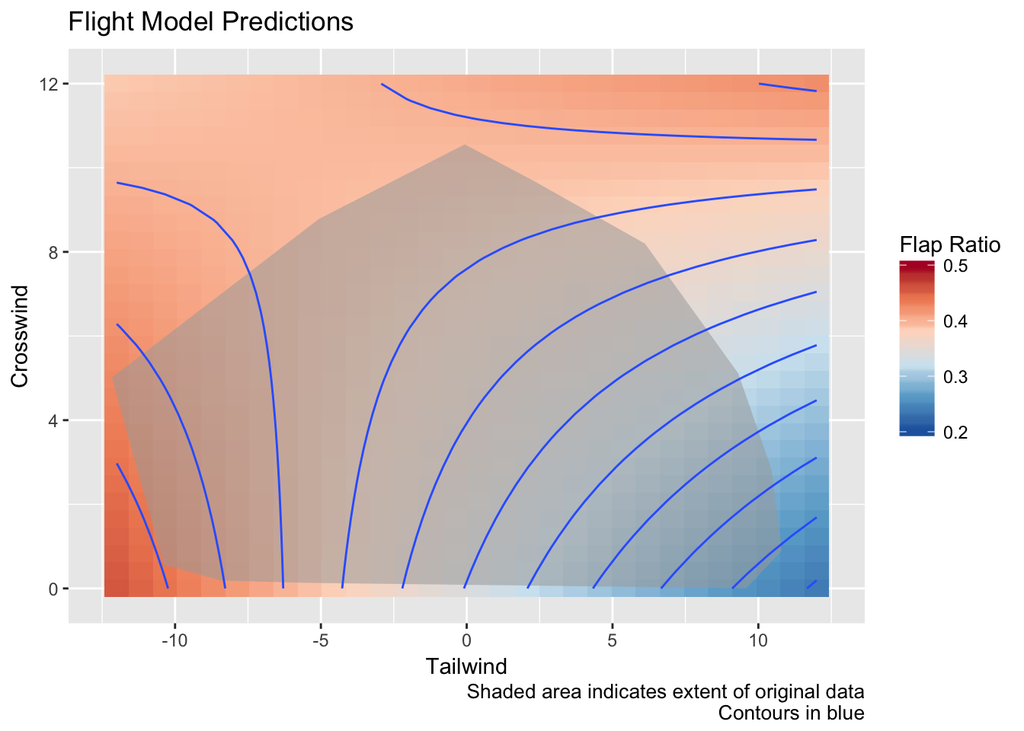

```r
cardinality <- 30
model.predictions <- expand.grid(Tailwind = seq(-12, 12, length.out = cardinality),
                                 Crosswind = seq(0, 12, length.out = cardinality)) %>%
  mutate(FlapRatio = predict(flight.model, newdata = ., type = 'response'))

# Get convex hulls of original data
segHulls <- segSample %>%
  do({
    pt_order <- with(., chull(Tailwind, Crosswind))
    pt_order_closed <- c(pt_order, pt_order[1])
    data.frame(Tailwind = .$Tailwind[pt_order_closed],
               Crosswind = .$Crosswind[pt_order_closed],
               stringsAsFactors = FALSE)
  })

ggplot(model.predictions, aes(x = Tailwind, y = Crosswind)) +
  geom_tile(aes(fill = FlapRatio)) +
  geom_polygon(data = segHulls, fill = 'darkgrey', alpha = 0.55) +
  geom_contour(aes(z = FlapRatio)) +
  scale_fill_distiller(type = 'div', palette = 'RdBu', limits = c(0.2, 0.5)) +
  labs(fill = 'Flap Ratio',
       title = 'Flight Model Predictions',
       caption = 'Shaded area indicates extent of original data\nContours in blue')
```